# Python and R

Seon Young Jhang 2023-11-12

## **Python and R**

### **3번. Next is part of data from PimaIndiansDiabetes **

- pregnant: number of times pregnant
- glucose: plasma glucose concentration(glucose tolerance test)
- pressure: diastolic blood pressure(mmHg)
- triceps: skinfold thickness(mm)
- insulin: 2-Hr serum insulin(mu U/ml)
- mass: body mass index(weight in Kg/(height in m)^2)
- pedigree: diabetes pedigree function
- age: age(years)
- diabetes: pos/neg

pima2.csv

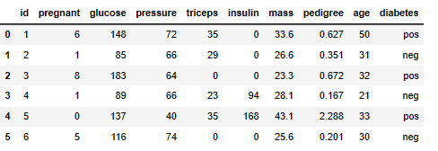

```r
knitr::include_graphics('diabetes_image.png')
```

document

```r
data <- read.csv("diabetes (1).csv")
```

#### **(1) Find the frequency and proportion of the variable diabetes by group, and draw them in bar plot and pie charts.**

Frequency/Frequency Table by pos, neg of variable diabetes

Data imported from the file

```r
head(data, 5)
```

```
##   id pregnant glucose pressure triceps insulin mass pedigree age diabetes
## 1  1        6     148       72      35       0 33.6    0.627  50      pos
## 2  2        1      85       66      29       0 26.6    0.351  31      neg
## 3  3        8     183       64       0       0 23.3    0.672  32      pos
## 4  4        1      89       66      23      94 28.1    0.167  21      neg
## 5  5        0     137       40      35     168 43.1    2.288  33      pos
```

Frequency of variable diabetes by pos, neg

```r
data_table <- table(data$diabetes)
```

Frequency table by pos, neg of variable diabetes

```r
data.freq = table(data$diabetes)
names(data.freq) = c("neg", "pos")
data.freq
```

```
## neg pos
## 500 268
```

Percentage of variable diabetes by pos, neg

*: The frequencies of neg and pos according to the variables diabetes are 500 and 268, respectively, and when expressed as a ratio, they are 65% and 35%, respectively.*

```r
count <- data_table
total <- sum(count)
frequency <- count / total
cat("빈도수:\n", count, "\n\n비율:\n", frequency, "\n")
```

```
## 빈도수:
##  500 268
##
## 비율:
##  0.6510417 0.3489583
```

Bar plots and Pie charts by groups on variable diabetes

*: Each Bar plots and Pie charts are drawn as follow:*

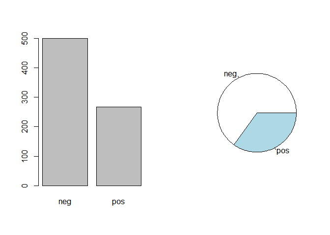

```r
par(mfrow=c(1,2))
#변수 diabetes 막대그래프
barplot(data.freq)
#변수 diabetes 원그림
pie(data.freq)
```

#### **(2) For each group of variables diabetes, find the minimum, maximum, median, mean, first quartile, and third quartile of variables (glucose, pressure, truthps, insulin, mass, fedigree, age). Additionally, draw, compare, and explain histograms and boxplots for each group of diabetes.**

Minimum, maximum, median, mean, first quartile, third quartile for each variable

*: ‘summary’ are used to know basic contents such as the minimum, maximum, median, average, first quartile, and third quartile of each variable, and the values are as follows*

```r
by(data, data$diabetes, summary)
```

```
## data$diabetes: neg
##        id           pregnant         glucose       pressure
##  Min.   :  2.0   Min.   : 0.000   Min.   :  0   Min.   :  0.00
##  1st Qu.:200.0   1st Qu.: 1.000   1st Qu.: 93   1st Qu.: 62.00
##  Median :405.0   Median : 2.000   Median :107   Median : 70.00
##  Mean   :391.8   Mean   : 3.298   Mean   :110   Mean   : 68.18
##  3rd Qu.:573.2   3rd Qu.: 5.000   3rd Qu.:125   3rd Qu.: 78.00
##  Max.   :768.0   Max.   :13.000   Max.   :197   Max.   :122.00
##     triceps         insulin            mass          pedigree
##  Min.   : 0.00   Min.   :  0.00   Min.   : 0.00   Min.   :0.0780
##  1st Qu.: 0.00   1st Qu.:  0.00   1st Qu.:25.40   1st Qu.:0.2298
##  Median :21.00   Median : 39.00   Median :30.05   Median :0.3360
##  Mean   :19.66   Mean   : 68.79   Mean   :30.30   Mean   :0.4297
##  3rd Qu.:31.00   3rd Qu.:105.00   3rd Qu.:35.30   3rd Qu.:0.5617
##  Max.   :60.00   Max.   :744.00   Max.   :57.30   Max.   :2.3290
##       age          diabetes
##  Min.   :21.00   Length:500
##  1st Qu.:23.00   Class :character
##  Median :27.00   Mode  :character
##  Mean   :31.19
##  3rd Qu.:37.00
##  Max.   :81.00
## ------------------------------------------------------------
## data$diabetes: pos
##        id           pregnant         glucose         pressure
##  Min.   :  1.0   Min.   : 0.000   Min.   :  0.0   Min.   :  0.00
##  1st Qu.:188.8   1st Qu.: 1.750   1st Qu.:119.0   1st Qu.: 66.00
##  Median :353.0   Median : 4.000   Median :140.0   Median : 74.00
##  Mean   :370.8   Mean   : 4.866   Mean   :141.3   Mean   : 70.82
##  3rd Qu.:582.0   3rd Qu.: 8.000   3rd Qu.:167.0   3rd Qu.: 82.00
##  Max.   :767.0   Max.   :17.000   Max.   :199.0   Max.   :114.00
##     triceps         insulin           mass          pedigree
##  Min.   : 0.00   Min.   :  0.0   Min.   : 0.00   Min.   :0.0880
##  1st Qu.: 0.00   1st Qu.:  0.0   1st Qu.:30.80   1st Qu.:0.2625
##  Median :27.00   Median :  0.0   Median :34.25   Median :0.4490
##  Mean   :22.16   Mean   :100.3   Mean   :35.14   Mean   :0.5505
##  3rd Qu.:36.00   3rd Qu.:167.2   3rd Qu.:38.77   3rd Qu.:0.7280
##  Max.   :99.00   Max.   :846.0   Max.   :67.10   Max.   :2.4200
##       age          diabetes
##  Min.   :21.00   Length:268
##  1st Qu.:28.00   Class :character
##  Median :36.00   Mode  :character
##  Mean   :37.07
##  3rd Qu.:44.00
##  Max.   :70.00
```

Histograms for each group in diabetes

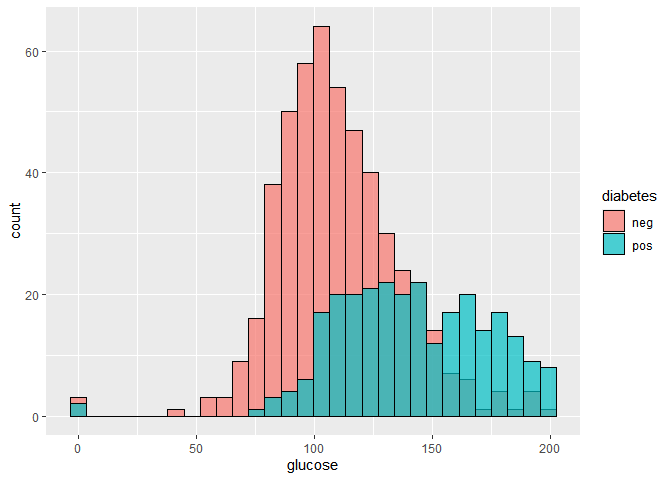

```r
library(ggplot2)
ggplot(data, aes(x = glucose, fill = diabetes)) +
  geom_histogram(position = "identity", alpha = 0.7, color = "black")
```

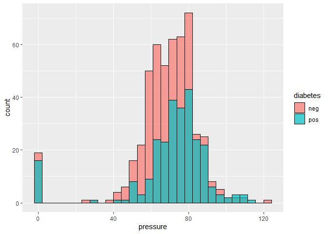

```r
ggplot(data, aes(x = pressure, fill = diabetes)) +
  geom_histogram(position = "identity", alpha = 0.7, color = "black")
```

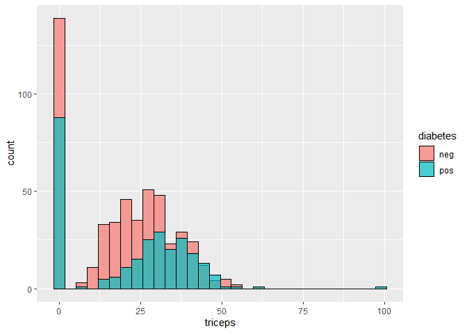

```r
ggplot(data, aes(x = triceps, fill = diabetes)) +
  geom_histogram(position = "identity", alpha = 0.7, color = "black")
```

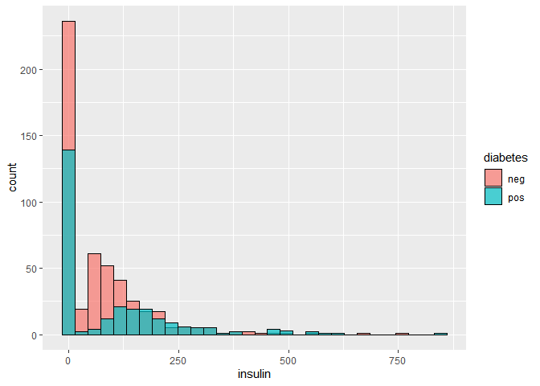

```r
ggplot(data, aes(x = insulin, fill = diabetes)) +
  geom_histogram(position = "identity", alpha = 0.7, color = "black")
```

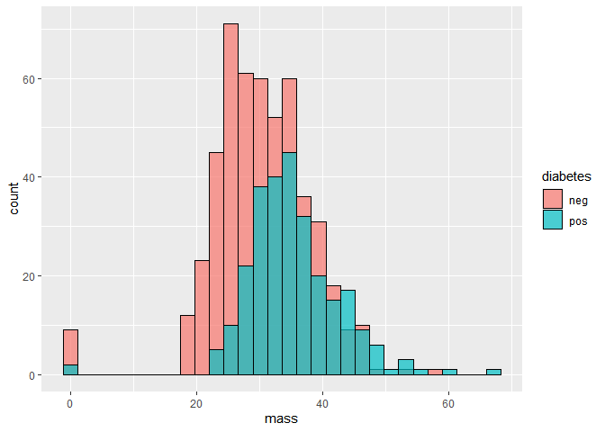

```r
ggplot(data, aes(x = mass, fill = diabetes)) +
  geom_histogram(position = "identity", alpha = 0.7, color = "black")
```

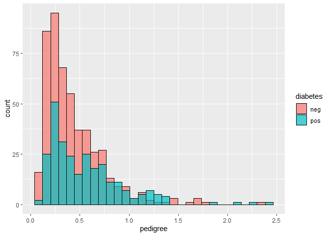

```r
ggplot(data, aes(x = pedigree, fill = diabetes)) +
  geom_histogram(position = "identity", alpha = 0.7, color = "black")
```

Boxplot for each group in diabetes

*: If you look at the boxplot similar to the histogram, the variable that shows the most significant difference between diabetes and neg and pos when viewed with the naked eye is glucose.*

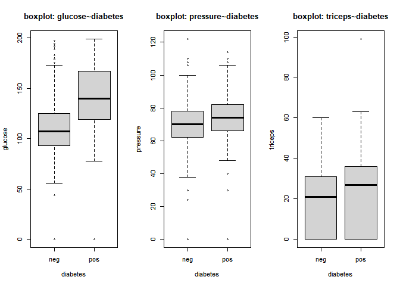

```r
par(mfrow=c(1,3))
boxplot(glucose ~ diabetes, data=data)
title("boxplot: glucose~diabetes")

boxplot(pressure ~ diabetes, data=data)
title("boxplot: pressure~diabetes")

boxplot(triceps ~ diabetes, data=data)
title("boxplot: triceps~diabetes")
```

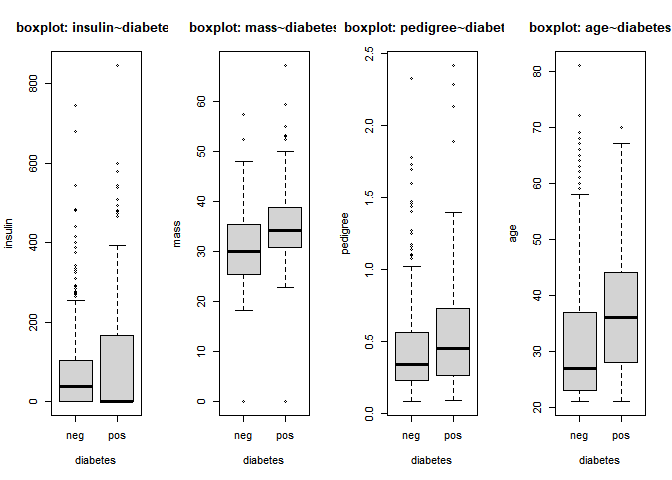

```r
par(mfrow=c(1,4))
boxplot(insulin ~ diabetes, data=data)
title("boxplot: insulin~diabetes")

boxplot(mass ~ diabetes, data=data)
title("boxplot: mass~diabetes")

boxplot(pedigree ~ diabetes, data=data)
title("boxplot: pedigree~diabetes")

boxplot(age ~ diabetes, data=data)
title("boxplot: age~diabetes")
```

#### **(3) Divide age into four groups: “20-30”, “31-40”, “41-50”, and “50+”, and find a table of division with diabetes. Also draw overlapping bars, compare and explain the distribution.**

Spliting age into four groups

*: A new derivative variable must be created in order for age to be divided into continuous variables and randomly grouped categories.*

```r
#age_category란 파생변수 만들기
data$age_category <- ifelse(data$age>=20 & data$age<=30, "20-30", ifelse(data$age>30 & data$age<=40, "31-40", ifelse(data$age>40 & data$age<=50, "41-50", "50+")))
```

Four groups of age and a split table on diabetes

*: The table of division with the diabetes of the four groups according to age is as follows.*

```r
#diabetes의 분할표
table(data$age_category)
```

```
##
## 20-30 31-40 41-50   50+
##   417   157   113    81
```

```r
data_table1 <- table(data$diabetes, data$age_category)
data_table1
```

```
##
##       20-30 31-40 41-50 50+
##   neg   327    81    49  43
##   pos    90    76    64  38
```

Diabetes bar plot by age group divided

*: If you look at the bar chart, 20-30 is the largest number, and in the diabetes 20-30 age group, neg is the majority, whereas in the 41-50 age group, pos overtakes neg.*

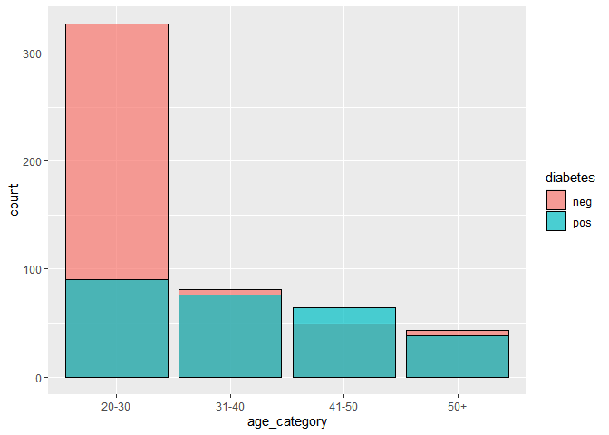

```r
library(ggplot2)
ggplot(data, aes(x = age_category, fill = diabetes)) +
  geom_bar(position = "identity", alpha = 0.7, color = "black")
```

#### **(4) Divide pregnant into three groups: “0-5”, “6-10”, and “10+”, and find a table of division with diabetes. Also draw overlapping bars, compare and explain the distribution.**

Divide pregnant into three groups

*:Similar to age, a new derivative variable must be created to arbitrarily divide the prepregant into group-type categories*

```r
#pregnant_category란 파생변수 만들기
data$pregnant_category <- ifelse(data$pregnant>=0 & data$pregnant<=5, "0-5", ifelse(data$pregnant>5 & data$pregnant<=10, "6-10", "10+"))
```

Three groups of pregnant and a split table on diabetes

*: The table of division with the diabetes of the three groups divided according to the number of prepregnant is as follows.*

```r
#diabetes의 분할표
table(data$pregnant_category)
```

```
##
##  0-5  10+ 6-10
##  549   34  185
```

```r
table(data$diabetes, data$pregnant_category)
```

```
##
##       0-5 10+ 6-10
##   neg 392  14   94
##   pos 157  20   91
```

Diabetes bar plot by pregnant group

*: Looking at the bar graphs of the three groups divided according to the number of pregnant, in the case of the 0-5 group, the neg of diabetes had more pos. However, in the case of 6-10 and 10+, the proportion of pos was higher, and in the 10+ group, it was more than neg. Through this, it can be inferred that the pos correlation between the number of prepregnant and diabetes is high.*

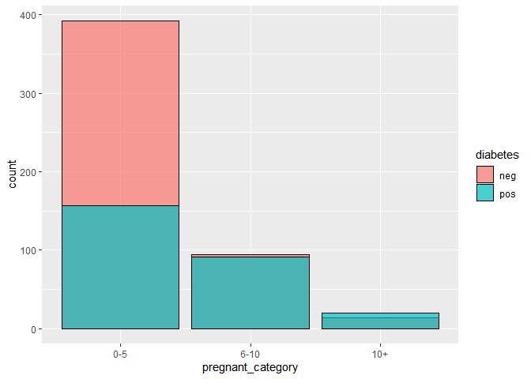

```r
#막대그리표
#category 순서 지정
data$pregnant_category <- factor(data$pregnant_category, levels = c('0-5', '6-10', '10+'))
ggplot(data, aes(x = pregnant_category, fill = diabetes)) +
  geom_bar(position = "identity", alpha = 0.7, color = "black")
```

```r
#glucose
xbar = tapply(data$glucose, data$pregnant_category, mean)
s = tapply(data$glucose, data$pregnant_category, sd)
n = tapply(data$glucose, data$pregnant_category, length)
cbind(mean=xbar, stdev=s, n=n)
```

```
##          mean    stdev   n
## 0-5  118.1020 31.07673 549
## 6-10 128.4703 34.40394 185
## 10+  124.7647 25.60192  34
```

```r
#pressure
xbar = tapply(data$pressure, data$pregnant_category, mean)
s = tapply(data$pressure, data$pregnant_category, sd)
n = tapply(data$pressure, data$pregnant_category, length)
cbind(mean=xbar, stdev=s, n=n)
```

```
##          mean    stdev   n
## 0-5  67.79781 18.94925 549
## 6-10 72.04865 19.67516 185
## 10+  74.20588 21.96937  34
```

```r
#triceps
xbar = tapply(data$triceps, data$pregnant_category, mean)
s = tapply(data$triceps, data$pregnant_category, sd)
n = tapply(data$triceps, data$pregnant_category, length)
cbind(mean=xbar, stdev=s, n=n)
```

```
##          mean    stdev   n
## 0-5  21.08015 15.59644 549
## 6-10 18.45946 16.65636 185
## 10+  23.05882 17.10563  34
```

```r
#insulin
xbar = tapply(data$insulin, data$pregnant_category, mean)
s = tapply(data$insulin, data$pregnant_category, sd)
n = tapply(data$insulin, data$pregnant_category, length)
cbind(mean=xbar, stdev=s, n=n)
```

```
##          mean     stdev   n
## 0-5  83.38069 116.18117 549
## 6-10 70.75676 116.14880 185
## 10+  71.17647  92.56757  34
```

```r
#mass
xbar = tapply(data$mass, data$pregnant_category, mean)
s = tapply(data$mass, data$pregnant_category, sd)
n = tapply(data$mass, data$pregnant_category, length)
cbind(mean=xbar, stdev=s, n=n)
```

```
##          mean    stdev   n
## 0-5  31.96922 8.024337 549
## 6-10 31.38216 7.483508 185
## 10+  35.69118 6.858146  34
```

```r
#pedigree
xbar = tapply(data$pedigree, data$pregnant_category, mean)
s = tapply(data$pedigree, data$pregnant_category, sd)
n = tapply(data$pedigree, data$pregnant_category, length)
cbind(mean=xbar, stdev=s, n=n)
```

```
##           mean     stdev   n
## 0-5  0.4726594 0.3413279 549
## 6-10 0.4699297 0.3058258 185
## 10+  0.4698235 0.3087132  34
```

```r
#age
xbar = tapply(data$age, data$pregnant_category, mean)
s = tapply(data$age, data$pregnant_category, sd)
n = tapply(data$age, data$pregnant_category, length)
cbind(mean=xbar, stdev=s, n=n)
```

```
##          mean     stdev   n
## 0-5  29.49180 10.248839 549
## 6-10 42.17297 10.402358 185
## 10+  45.17647  6.244855  34
```